# l7_2_en

Research Seminar

Week 8: Qual (ethnography) and feedback rounds

Sergi Martínez

smsoler@clio.uc3m.es | Office hours: Tues 10:00–13:00 (mail first)

## Today

- Oct 30:
  - Ethnography
  - Feedback rounds
- November 2:
  - No class
  - The assignment must be submitted via Aula Global
- November 6:
  - Class: Multivariate regression [readings: Fearon and Bolet]

## Second submission: Rubric

[output not shown]

## Example: Parkinson [purely qual]

[interactive chart not shown]

## Example: Ammassari [mixed method short]

[interactive chart not shown]

## Example: Amat [mixed method long]

[interactive chart not shown]

**Qualitative methods**

## Types of qualitative data

|  | People | Text |
| --- | --- | --- |
| Research context | Interviews Discussion/focus groups | Diaries and notes (requested) Open-ended questionnaires |
| “Real world” | Observational research (ethnography) | Discourse analysis Review of secondary sources (existing documents) |

## Process tracing vs. case study

Causal-Process Tracing (CPT) “how” questions by focusing on the causal conditions, configurations and mechanisms which make a specific outcome possible

- It is **outcome (Y)-centred**: the researcher is interested in the many and complex causes of a specific outcome, not so much in the effects of a specific cause (X)
- CPT is geared to answer questions like “why did this (Y) happen?” by documenting how

**Case studies**, instead:

| Feature | Case study (general design) | Process tracing (within-case method) |
| --- | --- | --- |
| **Primary scope** | An all-encompassing investigation of one or two units (organizations, event, or countries) to answer”why” questions through the counterfactual setting | An examination of the intervening steps and mechanisms connecting X to Y |
| **Causal focus** | Descriptive, exploratory, or comparative; may only show that an outcome happened or what factors correlated | Focuses on *how* it happened by opening the “black box” of causality |
| **Type of evidence** | Wide variety of qualitative or quantitative data (interviews, broad histories, macro-trends, archives) | “Hoop tests” (necessary evidence) and “smoking gun” tests (conclusive evidence) |
| **Relationship** | The macro-container or research strategy | A specific tool deployed *inside* a case study to strengthen causal inference |

## Example: The Cuban Missile Crisis

How the US decided to implement a naval blockade instead of launching an immediate airstrike, October 1962

**1. Broad case study approach**

Zooms out to understand the whole event, its context, and the macro variables at play

- **Goal**: describe the event comprehensively and identify the macro-factors that influenced the outcome
- **Evidence**: White House memos, troop movement logs, the JFK–Khrushchev letters, public speeches
- **Execution**: the researcher looks at the whole picture, writing a narrative showing that domestic political pressure, Soviet miscalculations, and US military readiness all intersected — a combination of rational calculation and bureaucratic politics led to the blockade
- **Limitation**: a rich, complete story, but it struggles to prove exactly which conversation or piece of information tilted JFK’s decision from war to diplomacy

**2. Process tracing approach**

Zooms in microscopically on the exact hours and days between October 16–22, 1962, treating the decision as a chain of falling dominoes

- **Goal**: open the “black box” of decision-making and prove the exact causal mechanism linking the problem (Soviet missiles discovered) to the final choice (the blockade)
- **Evidence**: minute-by-minute transcripts and audio recordings of the ExComm meetings — explicit diagnostic evidence that proves one theory while disqualifying another
- **Execution**: tests a specific theory — did fear of a nuclear counter-strike drive the blockade choice, or was it McNamara’s advice? The researcher tracks the timeline minute-by-minute, looking for a **smoking gun**: e.g., an audio recording where JFK explicitly states “An airstrike will force them to bomb Berlin, so we must use a blockade instead.” Finding that exact link proves the causal mechanism

Same case, two different questions: the case study asks *what explains the blockade, broadly*; process tracing asks *which exact link in the chain forced JFK’s hand*

## Case study: Kantola and Lombardo

*Kantola, J., & Lombardo, E. (2019). Populism and feminist politics: The cases of Finland and Spain. European Journal of Political Research, 58(4), 1108-1128.*

Case studies to understand how populist parties are linked to feminism - Cases: the Finnish far right and Podemos. Is the case selection well justified?

Institutional analyses - Formal. Are they similar or comparable? - Informal. Are they similar or comparable?

Materials and sources

- Interviews with women in the parties
- Secondary sources: manifestos, communication, policy proposals

[interactive chart not shown]

## Process tracing: Pavone et al.

Pavone, T., & Stiansen, Ø. (2022). The shadow effect of courts: Judicial review and the politics of preemptive reform. American Political Science Review, 116(1), 322-336.

Shadow effect of courts: their mere existence can lead independent agencies to push for policy reforms

- The case of Norway and EU law
- Policy: denial of social benefits to tourists and to people who returned to their countries of origin
- Data: internal (confidential) communication —letters and emails— between EFTA and the Norwegian Government (NAV), with far-right people from the NIC (an independent agency)

[interactive chart not shown]

## Class activity: critique

- Argument: including armed groups in democratic processes without securing peace may raise killings of politicians and trigger revenge dynamics
- Case: the Colombian civil war and the FARC-EP–Unión Patriótica
- Quantitative findings: $\Delta$ killings of traditional politicians in t-1 -> $\Delta$ killings of non-traditional politicians in t, if that municipality had shifted control
- Qualitative hypothesis:
  - If we are right: we should observe that assassinations were directed (ordered) for political reasons, across ideological and political parties
  - If we are right: we should observe that this directionality of violence is justified by previous assassinations
- Qualitative evidence: process tracing using memoirs, confessions to police and judiciary, and interviews

[interactive chart not shown]

**Ethnography**

## Ethnography

**Ethnography:** A descriptive study of a particular human society based on immersion in that society

- *“Immersion in this sense then, involves being with people to observe how they respond to events, experiencing for oneself these events and their circumstances, and being able to interpret the sensitivities and meanings of their conversations to each other.”*
- *“Being immerse in a society to live and observe it without losing sight of our own scientific goal—that is, without going native.”*

Goal of this inmersion: obtaining informal and formal interviews, life histories, archival research, and detailed field notes

Main characteristics:

- **Full immersion** of the researcher in the culture and everyday life
- **Prolonged fieldwork** vs. superficial observation
- **Real, holistic context**, a.k.a. people don’t operate in a vacuum
- Typically used to build theories [**theory building**], but it can also be used as a theory-testing tool

## Ethnography vs. other methods

Comes from anthropology:

| Method | Context | Immersion | Duration |
| --- | --- | --- | --- |
| Ethnography | High | Total | Extended |
| Surveys | Low | None | Punctual |
| RCTs | Controlled | None | Brief |
| Institutional Analysis | Formal | Limited | Variable |

**Does NOT break down** individuals into parts for variables **DOES study** real interactions with institutions and organizations

## An example: Scott

James Scott

- People do not only show discomfort by revolting; there are daily forms of resistance
- People with low resources do whatever they can [hidden transcript]:
  - footdragging
  - slowness
  - feigned ignorance
  - sabotage
  - little theft

[figure not shown]

Ethnography helps expand the methodological toolbox of political inquiry because they allow one to see different things and to see things differently

## An example: working with bonobos

[figure not shown]

The main differences between bonobos and chimpanzees have to do with behavior, and the most obvious ones with sex. Both in captivity and in the wild, bonobos engage in a remarkable diversity of sexual interactions. According to De Waal: «While chimpanzees show little variation in the sexual act, bonobos behave as if they had read the Kama Sutra, adopting every imaginable position and variation». For example, they mate in the missionary position, something practically unknown among chimpanzees.

## Another example: The moral of the story

[video not shown]

## Another example: Strangers in the…

1. https://www.youtube.com/watch?v=ZwAERaRUsp0
2. https://www.youtube.com/watch?v=mQhBoY4KYHY
3. Strangers in their own land, by Arlie Hochschild

[figure not shown]

## Strangers in their own land (I)

- **Motivation for the book**: understanding the right [Why?].
- **Paradox**/puzzle:

How can it be that the poorest people, with the worst living conditions, in the states that draw the most on (federal) state resources, vote for the right and defend shrinking the state?

Are the most polluted the ones who want the least environmental regulation?

[figure not shown]

## Strangers in their own land (II): Method

*The Cappel home became my home away from home as I began interviews around Lake Charles and elsewhere around the state on what became ten expeditions between 2011 and 2016.*

- 4 focus groups
- 60 interviews (and follow-ups): 40 with Tea Party members and 20 to help understand them
- Breakfasts and lunches with local associations, churches, fairs, contests, local festivals, etc.
- 4,000 pages of transcripts and field notes

## Strangers in their own land (III): Findings

*Deep story*: they are history’s losers, the American nightmare, forgotten in their own country

- It’s not just economics, it’s identity and social recognition
- Within *the other camp*, there’s a bit of everything

[figure not shown]

## Another example: Berenschot

[figure not shown]

- A political scientist who defines himself as an anthropologist
- Professor at the University of Amsterdam.
- https://informalpolitics.org/ or **Everyday mediation**

## Motivation

- NGOs and international organizations see politicians as
1. Policy makers, implementing their ideology and proposals
2. Supervisors of the providers of those policies
- **But politics, like life, is complicated**: the state [with low/variable capacities] vs. / ft. citizens [civil society, political parties, the citizenry, bureaucracy, etc.]

## What is the role of politicians in that situation?

## Theory

[Disclaimer: ethnography is *theory building*, but I’m going to present it as a positivist article]

- Politicians as intermediaries: the game of telephone, or the translator

[video not shown]

**Where the market fails and institutions don’t reach, politicians mediate and facilitate solutions**

- It is not an intrusion or an aberration for a politician to shape the state’s operations
- Political intermediation as a *necessary evil*, but a necessary one
- **The mediated state** as a solution and an *electoral-dependency* strategy through the monopoly of the network

## Case study

- The world’s most populous democracy (at risk, according to V-Dem) [1.4 billion people; Gujarat is a tiny region of 60 million people]
- BRICS (an emerging and unequal economy, even if data like the GINI index say otherwise)
- A state with variable capacities depending on geography
- Fragmented sovereignty, the provision of basic services (health, education, etc.)

## Pravin Dalal (I)

Berenschot follows a council member’s day-to-day life to see his role.

Pravin is a municipal representative of the BJP, India’s most important party, especially among the Hindu population, in a context of an incapable state’s expansion

- A good politician = one who distributes resources and manipulates implementation as long as it works
- Once elected, he became a **street-level politician**
- First half of the day: listening to and collecting citizens’ **problems** (*tamaru kam thai jaashe*).

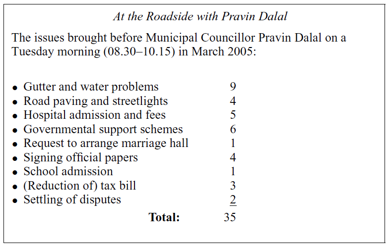

## Pravin Dalal (II)

- Second half of the day: distributing tasks among the thematic officers of the municipal office (neighborhood, ward), contacting his *helpers* to check whether the clerks are acting

1. Making things happen
2. Developing the capacity to control the distribution of resources to benefit his voters/potential voters
3. Getting bureaucrats and policy-makers in his pocket to accomplish the second task
- India’s majoritarian system promotes these dynamics (racist, exclusionary, corruption-traps)

[figure not shown]

**Feedback rounds**

## Feedback round

| Presenting group | Commenter 1 | Commenter 2 |
| --- | --- | --- |
| **Group 1** | Group 7 | Group 3 |
| **Group 2** | Group 6 | Group 1 |
| **Group 3** | Group 2 | Group 6 |
| **Group 6** | Group 1 | Group 7 |
| **Group 7** | Group 3 | Group 2 |

10:00

min

## See you next Friday! Any question at smsoler@clio.uc3m.es

Research Seminar